# Motivation

Front month futures contracts dominate futures trading volume. Leading up to a particular front month expiry, many thus 'roll' their position over to the next front month contract. This process can lead to mispricings around the roll. A mean reversion algorithm was thus applied to the calendar price spread between front two month futures contracts of various index and commodity futures in this volatile period. The algorithm bets that deviations from long established calendar price spreads are more likely to be mispricings resulting from roll volatility than legitimate price discovery. Brent oil futures are used here as an example.

```python
import pandas as pd
import numpy as np
import matplotlib.pyplot as plt

df = pd.read_csv('Data/lco.csv')
df['Date-Time'] = pd.to_datetime(df['Date-Time'], errors='coerce')

# Create a dictionary of dataframes, each with a unique #RIC value as the key
unique_ric_values = df['#RIC'].unique()
dfs = {ric: df[df['#RIC'] == ric] for ric in unique_ric_values}
dfs[unique_ric_values[-1]]
```

|  | #RIC | Domain | Date-Time | GMT Offset | Type | Close Bid | Close Ask | Close Bid Size | Close Ask Size |
| --- | --- | --- | --- | --- | --- | --- | --- | --- | --- |
| 59656637 | LCOZ5 | Market Price | 2024-01-02 01:00:00+00:00 | 0 | Intraday 5Sec | 72.28 | 72.36 | 1.0 | 3.0 |
| 59656638 | LCOZ5 | Market Price | 2024-01-02 01:00:05+00:00 | 0 | Intraday 5Sec | 72.25 | 72.36 | 1.0 | 1.0 |
| 59656639 | LCOZ5 | Market Price | 2024-01-02 01:00:10+00:00 | 0 | Intraday 5Sec | 72.26 | 72.38 | 1.0 | 2.0 |
| 59656640 | LCOZ5 | Market Price | 2024-01-02 01:00:15+00:00 | 0 | Intraday 5Sec | 72.25 | 72.38 | 1.0 | 2.0 |
| 59656641 | LCOZ5 | Market Price | 2024-01-02 01:00:20+00:00 | 0 | Intraday 5Sec | 72.28 | 72.38 | 1.0 | 1.0 |
| ... | ... | ... | ... | ... | ... | ... | ... | ... | ... |
| 65747217 | LCOZ5 | Market Price | 2025-09-12 17:29:35+00:00 | 1 | Intraday 5Sec | 66.40 | 66.41 | 12.0 | 9.0 |
| 65747218 | LCOZ5 | Market Price | 2025-09-12 17:29:40+00:00 | 1 | Intraday 5Sec | 66.40 | 66.41 | 12.0 | 11.0 |
| 65747219 | LCOZ5 | Market Price | 2025-09-12 17:29:45+00:00 | 1 | Intraday 5Sec | 66.40 | 66.41 | 9.0 | 7.0 |
| 65747220 | LCOZ5 | Market Price | 2025-09-12 17:29:50+00:00 | 1 | Intraday 5Sec | 66.40 | 66.41 | 19.0 | 5.0 |
| 65747221 | LCOZ5 | Market Price | 2025-09-12 17:29:55+00:00 | 1 | Intraday 5Sec | 66.39 | 66.40 | 10.0 | 10.0 |

6090585 rows × 9 columns

# Backtest Data

2 years of 5 secondly, brent oil futures data was collected from Refinitiv Datascope. Given that there are monthly expiries of this contract, the strategy was tested on dozens of front month roll periods. Specifically, the mean reversion algorithm was only applied on exact expiry days where volatility is most noticeable. Below, the data is explored, cleaned and then examples of calendar price spreads between front 2 month contracts (and their mean reverting behaviour) on these days are plotted.

```python
#trading hours

df1 = dfs[unique_ric_values[0]].copy()

# Convert the 'Date-Time' column to datetime
df1['Date-Time'] = pd.to_datetime(df1['Date-Time'], errors='coerce')

# Extract the day of the week and hour from the 'Date-Time' column
df1['DayOfWeek'] = df1['Date-Time'].dt.day_name()
df1['Hour'] = df1['Date-Time'].dt.hour

# Get unique days of the week
unique_days = df1['DayOfWeek'].unique()

# Dictionary to store unique hours for each day of the week
unique_hours_per_day = {}

# Iterate over each unique day of the week
for day in unique_days:
    # Get unique hours for the current day
    unique_hours = df1[df1['DayOfWeek'] == day]['Hour'].unique()
    unique_hours_per_day[day] = unique_hours

{day: np.sort(hours) for day, hours in unique_hours_per_day.items()}
```

```
{'Tuesday': array([ 0,  1,  2,  3,  4,  5,  6,  7,  8,  9, 10, 11, 12, 13, 14, 15, 16,
        17, 18, 19, 20, 21, 22, 23], dtype=int32),
 'Wednesday': array([ 0,  1,  2,  3,  4,  5,  6,  7,  8,  9, 10, 11, 12, 13, 14, 15, 16,
        17, 18, 19, 20, 21, 22], dtype=int32),
 'Thursday': array([ 0,  1,  2,  3,  4,  5,  6,  7,  8,  9, 10, 11, 12, 13, 14, 15, 16,
        17, 18, 19, 20, 21, 22, 23], dtype=int32),
 'Friday': array([ 0,  1,  2,  3,  4,  5,  6,  7,  8,  9, 10, 11, 12, 13, 14, 15, 16,
        17, 18, 19, 20, 21, 22], dtype=int32),
 'Sunday': array([22, 23], dtype=int32),
 'Monday': array([ 0,  1,  2,  3,  4,  5,  6,  7,  8,  9, 10, 11, 12, 13, 14, 15, 16,
        17, 18, 19, 20, 21, 22], dtype=int32)}
```

```
0
```

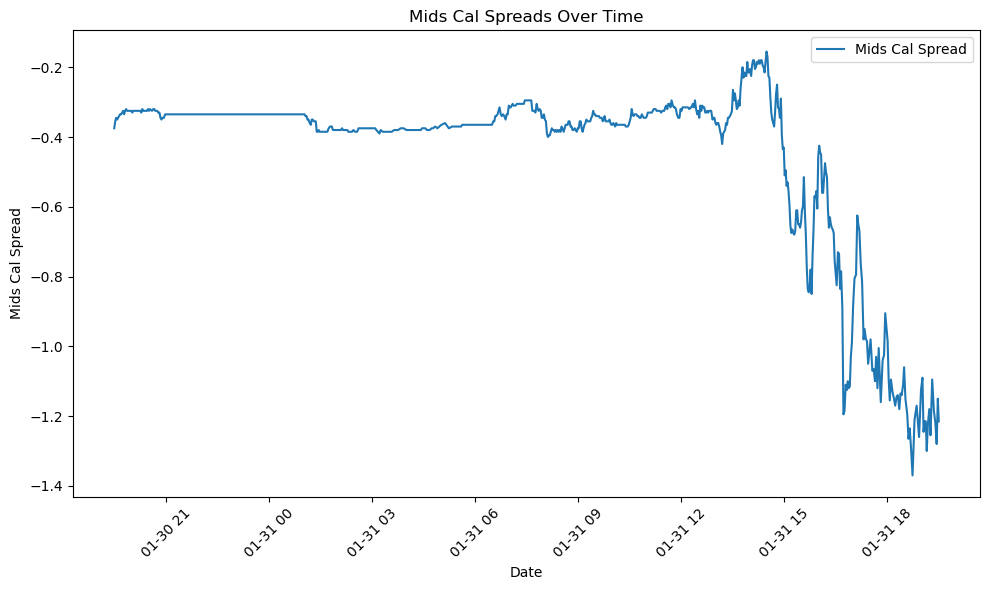

```
1
```

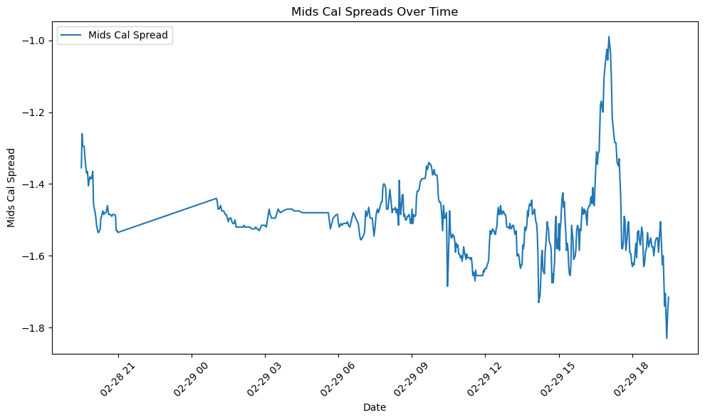

```
2
```

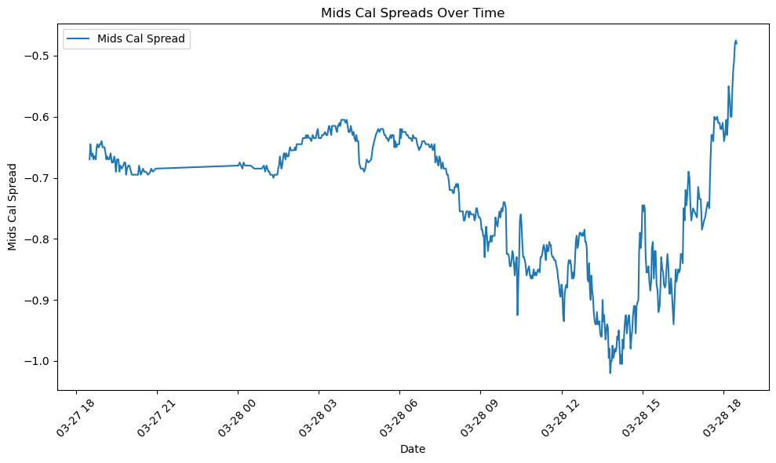

```
3
```

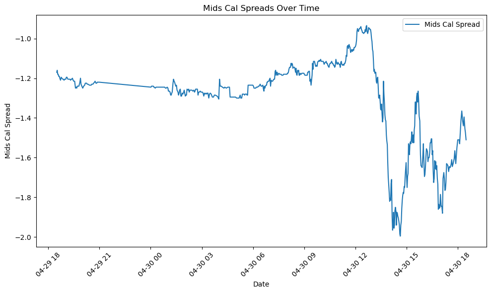

```
4
```

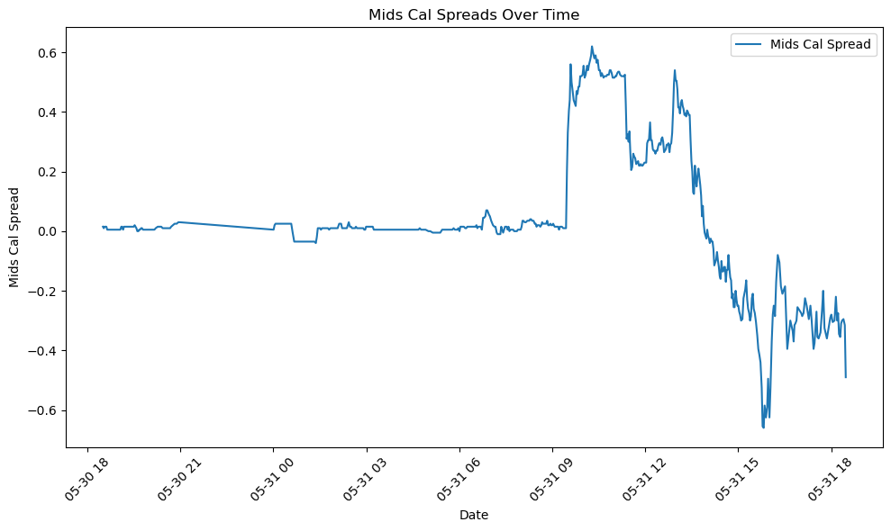

```
5
```

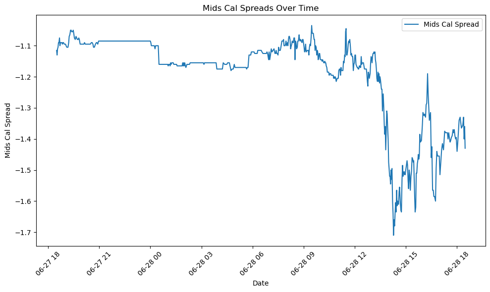

```
6
```

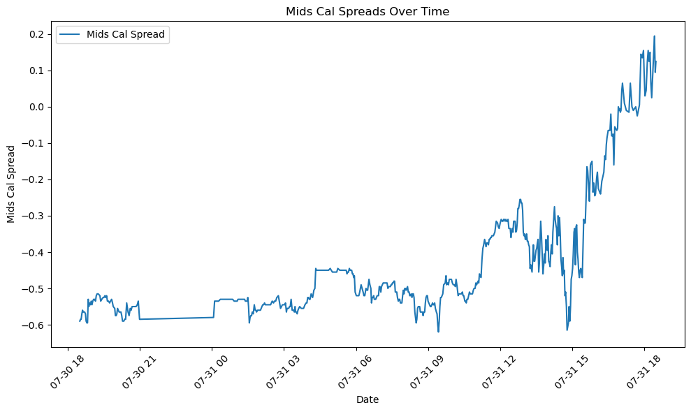

```
7
```

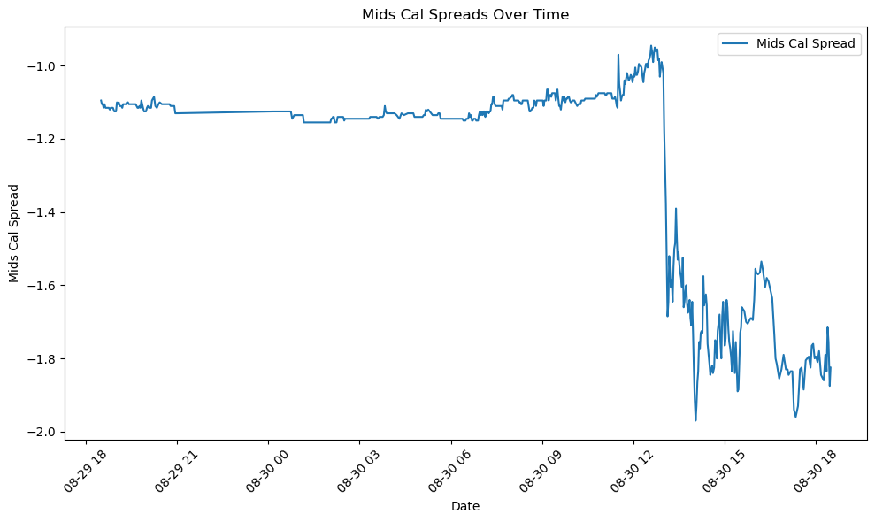

```
8
```

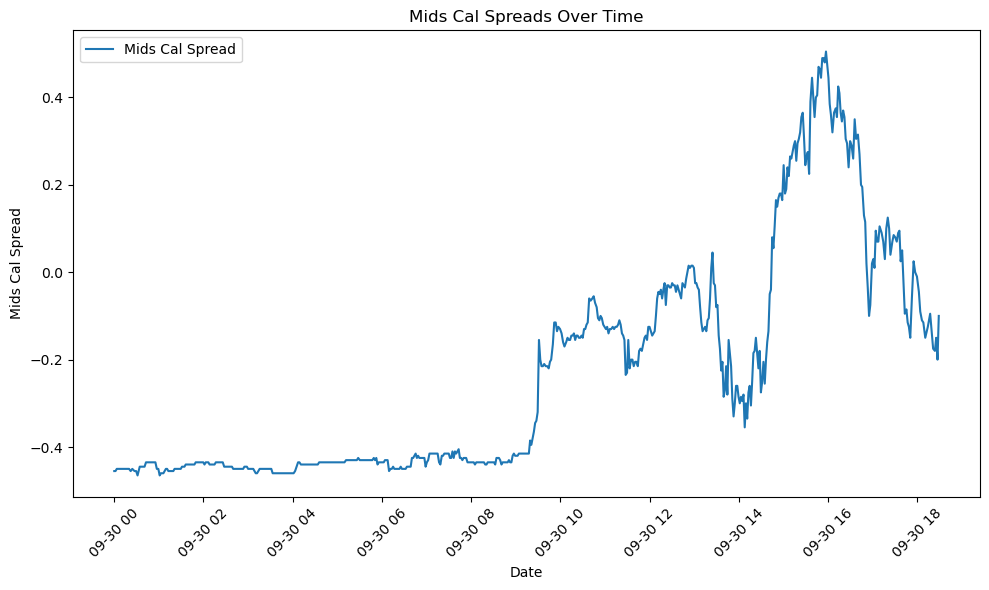

```
9
```

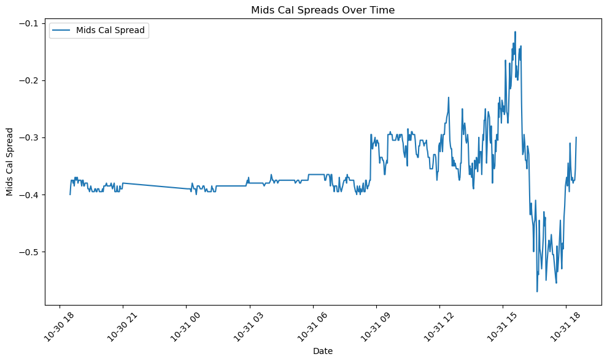

```
10
```

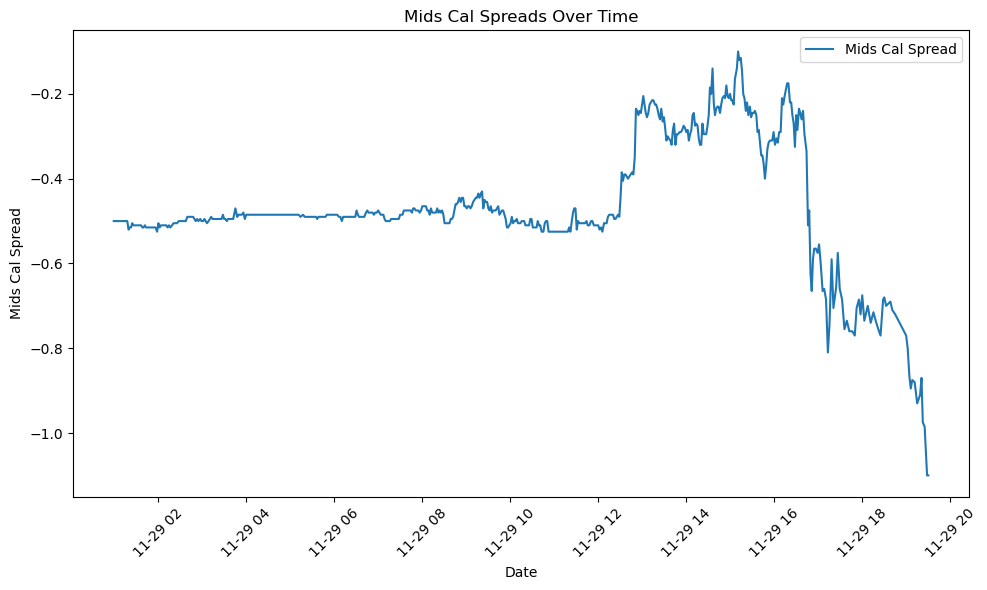

```
11
```

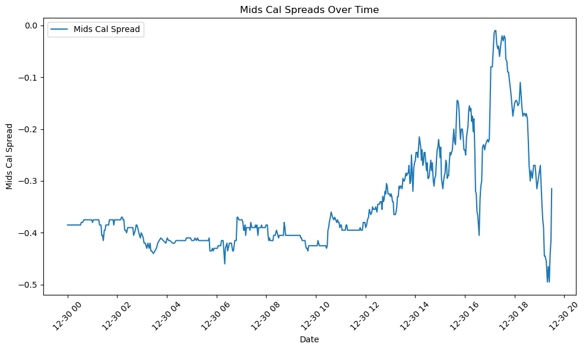

```
12
```

[9 more figures not shown]

```
21
```

```
[        #RIC        Domain                      date  GMT Offset  \
 0      LCOX5  Market Price 2025-09-11 17:29:55+00:00           1
 1      LCOX5  Market Price 2025-09-11 17:30:00+00:00           1
 2      LCOX5  Market Price 2025-09-11 17:30:05+00:00           1
 3      LCOX5  Market Price 2025-09-11 17:30:10+00:00           1
 4      LCOX5  Market Price 2025-09-11 17:30:15+00:00           1
 ...      ...           ...                       ...         ...
 13643  LCOX5  Market Price 2025-09-12 17:29:35+00:00           1
 13644  LCOX5  Market Price 2025-09-12 17:29:40+00:00           1
 13645  LCOX5  Market Price 2025-09-12 17:29:45+00:00           1
 13646  LCOX5  Market Price 2025-09-12 17:29:50+00:00           1
 13647  LCOX5  Market Price 2025-09-12 17:29:55+00:00           1

                 Type    bid    ask  Close Bid Size  Close Ask Size
 0      Intraday 5Sec  66.39  66.40             8.0            11.0
```

[output cut: 39 more lines]

```python
#Make dfe and dfl collections: A contract and its two laters

#Sort by date
rics = df['#RIC'].loc[df['#RIC'].shift() != df['#RIC']].tolist()
rics = sorted(rics, key=lambda x: (x[-1], x[-2]))

dfels = []
close_times = []
for member in range(len(rics)):
    print(member)
    ric = rics[member]
    if ric == rics[-1]:
        break

    dfe = dfs[ric]
    for partner in range(1,2):
        ricl = rics[member+partner]
        dfl = dfs[ricl]

        #Remove rows with no bid or ask quotes
        missingl = dfl[['Close Bid', 'Close Ask']].isna().any(axis=1)
        dfl_filtered = dfl[~missingl]
        missinge = dfe[['Close Bid', 'Close Ask']].isna().any(axis=1)
        dfe_filtered = dfe[~missinge]

        #Remove rows outside of regular trading hours
        dfl_filtered = dfl_filtered[~dfl_filtered['Date-Time'].dt.hour.isin([21,22,23])]
        dfe_filtered = dfe_filtered[~dfe_filtered['Date-Time'].dt.hour.isin([21,22,23])]

        #Only ever trade front month pairs
        last_date_dfe = dfe_filtered['Date-Time'].max()
        three_month_prior = last_date_dfe - pd.DateOffset(days=1)
        dfe_filtered = dfe_filtered[dfe_filtered['Date-Time'] >= three_month_prior]
        start_closing = last_date_dfe - pd.DateOffset(minutes=1)
        close_times.append(start_closing)

        #Filter so that only rows with a datetime in dfl and dfe are kept
        common_datese = dfe_filtered['Date-Time'].isin(dfl_filtered['Date-Time'])
        common_datesl = dfl_filtered['Date-Time'].isin(dfe_filtered['Date-Time'])
        dfe_filtered = dfe_filtered[common_datese]
        dfl_filtered = dfl_filtered[common_datesl]

        dfe_filtered = dfe_filtered.rename(columns={'Close Bid': 'bid', 'Close Ask': 'ask', 'Date-Time': 'date'}).reset_index(drop=True)
        dfl_filtered = dfl_filtered.rename(columns={'Close Bid': 'bid', 'Close Ask': 'ask', 'Date-Time': 'date'}).reset_index(drop=True)

        plt.figure(figsize=(10, 6))
        plt.plot(pd.to_datetime(dfe_filtered['date'])[::20], ((dfl_filtered['ask'] - dfe_filtered['bid'] + dfl_filtered['bid'] - dfe_filtered['ask'])/2)[::20], label='Mids Cal Spread')
        plt.xlabel('Date')
        plt.ylabel('Mids Cal Spread')
        plt.title('Mids Cal Spreads Over Time')
        plt.xticks(rotation=45)
        # plt.ylim(-1, 50)  # Set y-axis limits
        plt.legend()
        plt.tight_layout()
        plt.show()

        dfels.append([dfe_filtered, dfl_filtered])

dfels[-1]
```

# Strategy

```
-0.8599999999999568
```

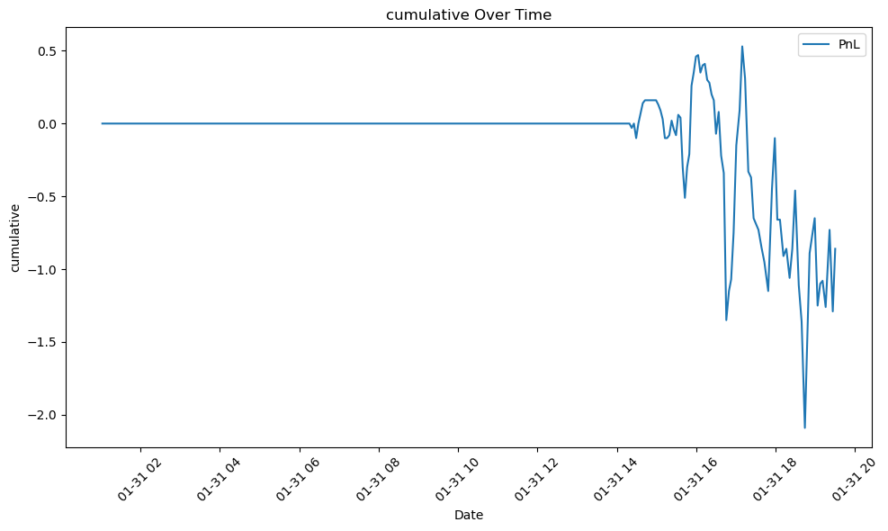

```
1.039999999999992
```

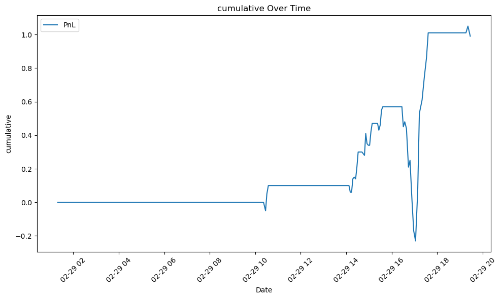

```
0.25
```

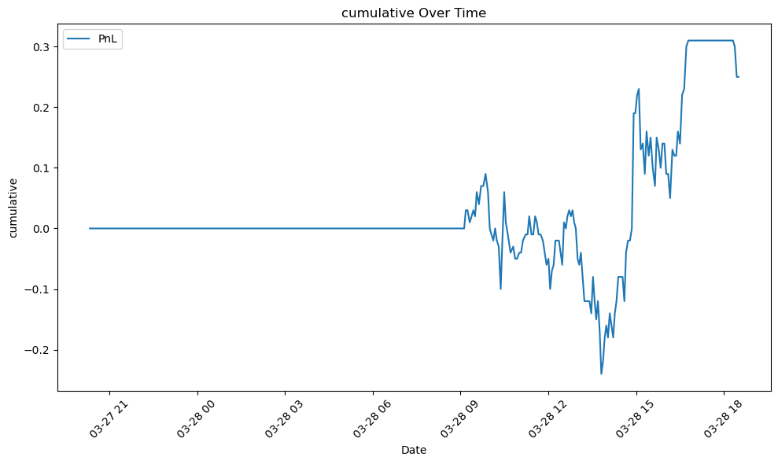

```
0.7900000000000205
```

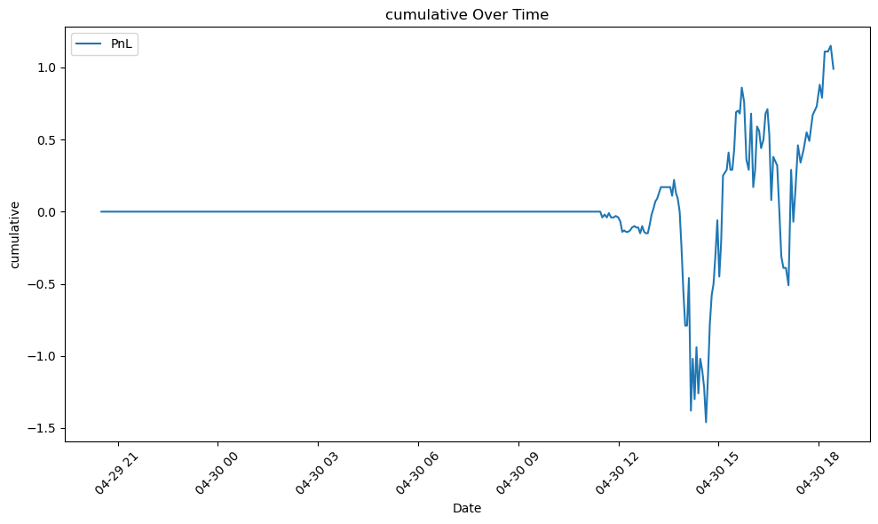

```
0.6100000000000136
```

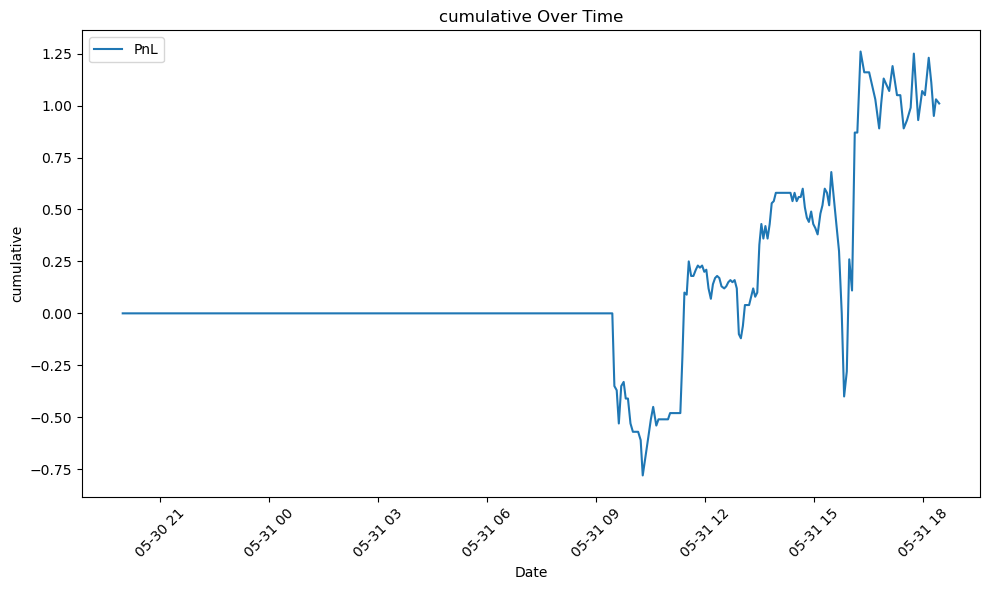

```
0.3599999999999852
```

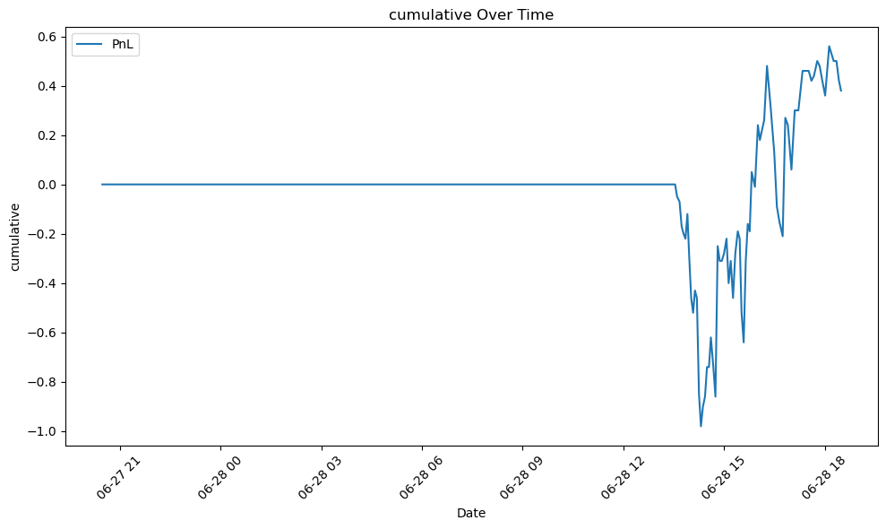

```
-0.9199999999999591
```

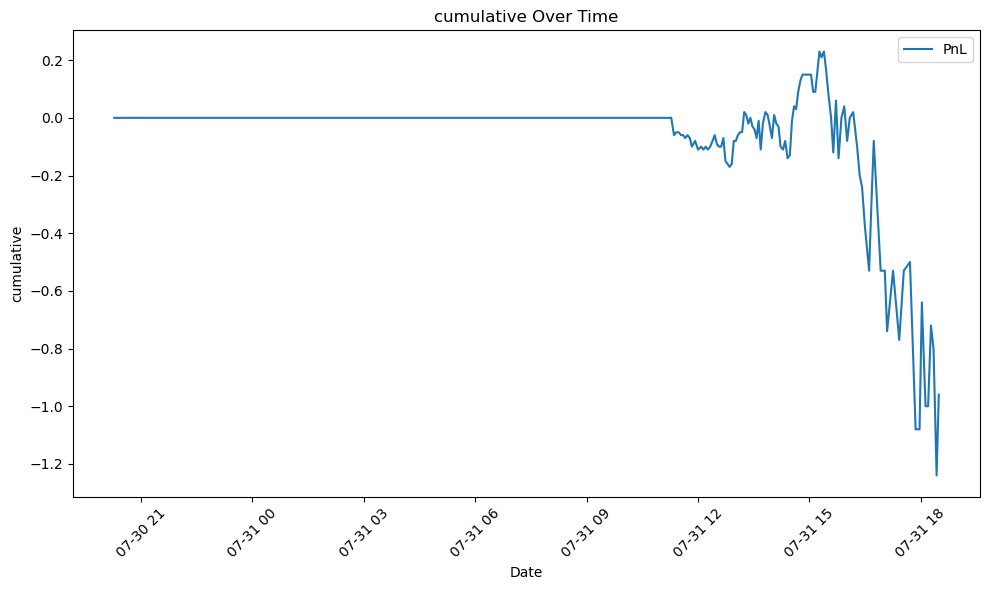

```
-0.2999999999999545
```

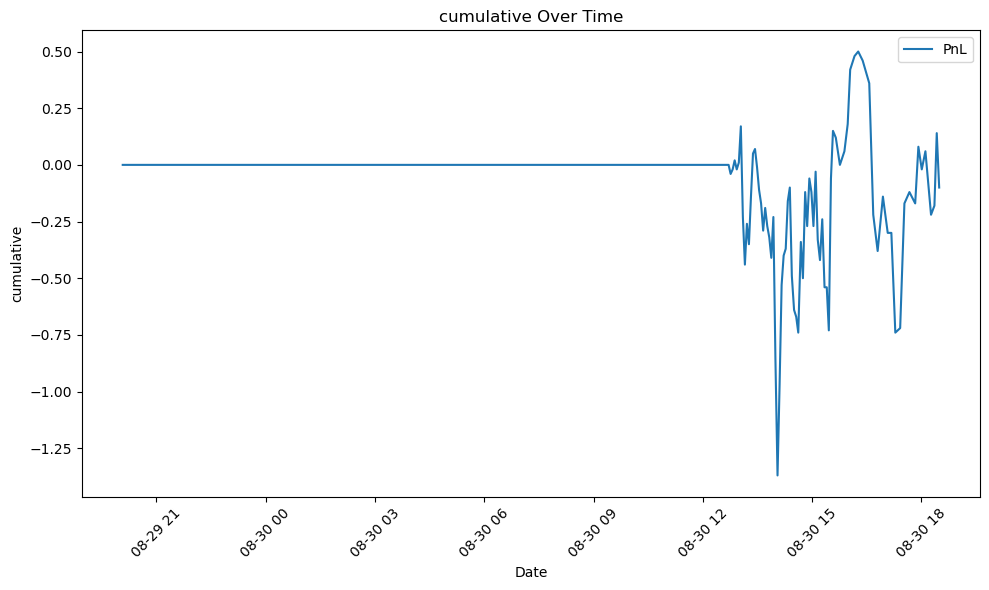

```
0.6300000000000239
```

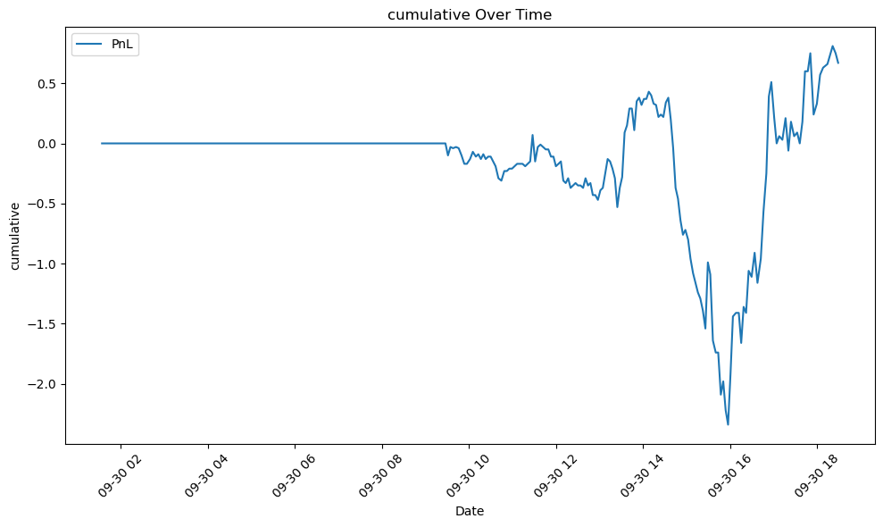

```
0.30999999999997385
```

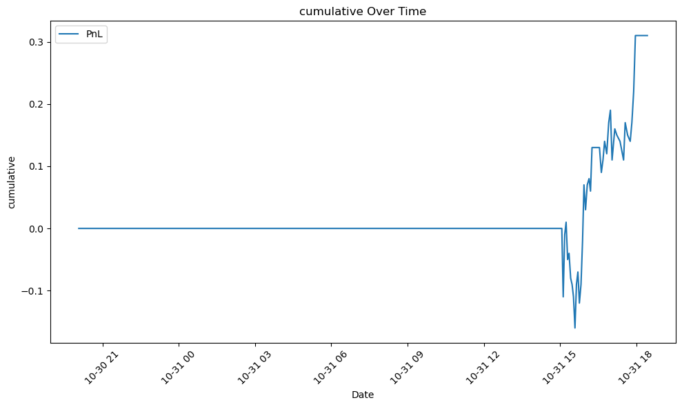

```
-1.2999999999999545
```

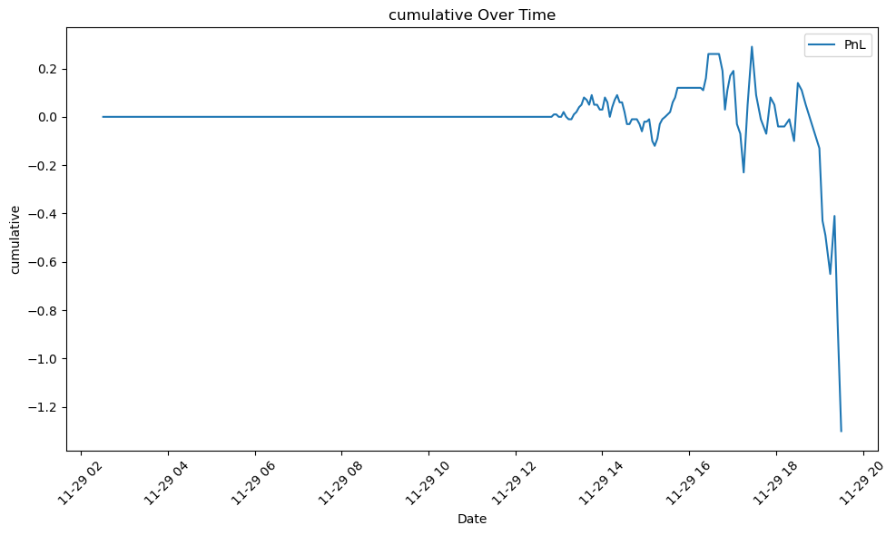

```
0.5399999999999778
```

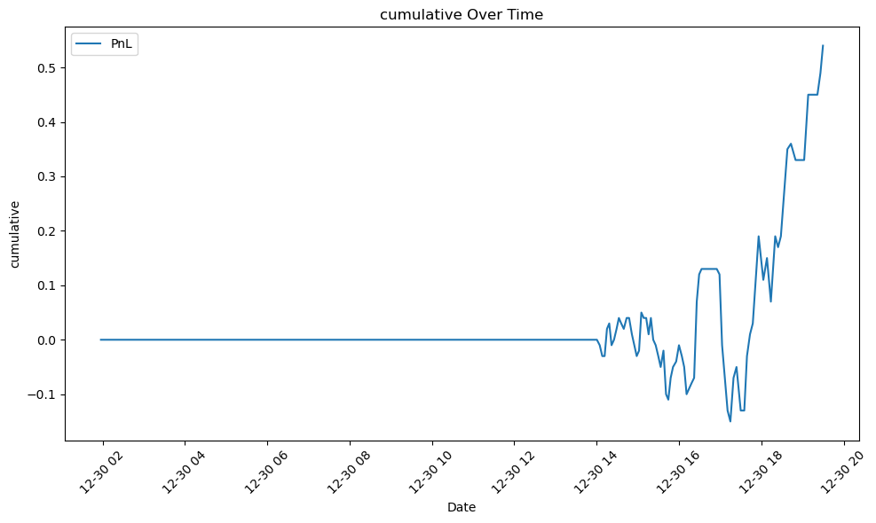

```
1.4099999999999824
```

[9 more figures not shown]

```python
from python_trading_functions import mean_reversion_algorithm

running_totals = []
for considered in range(len(dfels)):
    dfe = dfels[considered][0]
    dfl = dfels[considered][1]
    start_closing = close_times[considered]

    result_df = pd.DataFrame(columns=['date', 'theo_spread', 'theo_value1', 'theo_value2', 'open_positions', 'amounte', 'amountl', 'cash', 'to_close_spread', 'cumulative', 'slippage'])

    rows = mean_reversion_algorithm(0.15, 1, start_closing)
    result_df = pd.DataFrame(rows, columns=result_df.columns)

    if result_df.shape[0] > 0:
        final_pnl = list(result_df['cumulative'])[-1]

        print(final_pnl)
        running_totals.append(final_pnl)

        result_df['date'] = pd.to_datetime(result_df['date'])
        result_df.sort_values(by='date', inplace=True)
        plt.figure(figsize=(10, 6))
        plt.plot(pd.to_datetime(result_df['date'])[::40], result_df['cumulative'][::40], label='PnL')
        plt.xlabel('Date')
        plt.ylabel('cumulative')
        plt.title('cumulative Over Time')
        plt.xticks(rotation=45)
        plt.legend()
        plt.tight_layout()
        plt.show()
```

# Results